# Ps_Allen_Rmarkdown

Allen Bolourchi

1/18/2021

## Preparation

As part of this assignment, you will construct a hedonic pricing model for diamonds, similar to how we constructed a hedonic pricing model in class for houses. Recall that upon running the model in class, we found b0 = 611896 and b1 = 531. This implies that if one house is 1 square foot larger than another, we expect the market to value the first house $531 more. And we expect a house with a size of 0 square feet to be valued at $611,896. (This latter estimate is well outside the range of the data, as we don’t see any houses that are 0 square feet, so its substantive interpretation is suspect.)

To start, load the `tidyverse` set of packages. Then load the `diamonds` dataset from the `ggplot2` package using the `data()` function. (In particular, use `data(diamonds)`. Rather than loading a dataset from an external .csv or .xlsx file, this will load it from the `ggplot2` package. The `ggplot2` package was loaded when you loaded the `tidyverse` packages.) We’ll focus on three variables from the `diamonds` dataset: `price` (in dollars), `carat` (representing the size of the diamond), and `cut` (representing the quality of the cut, which influences its ability to reflect light and sparkle.) Use the `table()` function and the `cut` variable from the `diamonds` dataset (i.e., `table(diamonds$cut)` to count the number of each type of cut. You should see that there are 21,551 “Ideal” cut diamonds in the dataset.

Next, create a new data frame called `ideal` consisting of only and all ideal diamonds from the `diamonds` data frame. You can do this using the `filter()` function as shown below:  
`ideal <- filter(diamonds, cut == "Ideal")`  
Verify that `ideal` has 21,551 observations and 10 variables in it, that `mean(ideal$carat)` gives you `0.702837`, and that `mean(ideal$price)` gives you `3457.542`. If you do not get those numbers (making an allowance for rounding), *something has gone wrong.* Make sure to fix it before moving on to the rest of the problem set. If you get really stuck, I can help you get to this point.

```r
library(tidyverse)
data("diamonds")
view(diamonds)
table(diamonds$cut)
```

```
##
##      Fair      Good Very Good   Premium     Ideal
##      1610      4906     12082     13791     21551
```

```r
ideal <- filter(diamonds, cut == "Ideal")
view(ideal)
mean(ideal$carat)
```

```
## [1] 0.702837
```

## Question 1

The `log()` function takes the natural logarithm (i.e., logarithm with base e ~= 2.72) of a number or vector. If e^z = x, then log(x) = z (this refers to the mathematical constant e, not e as in error or residual). This function has the effect of compressing large values. Consider the relationship between x and log(x) as shown in the plot generated by the code below:

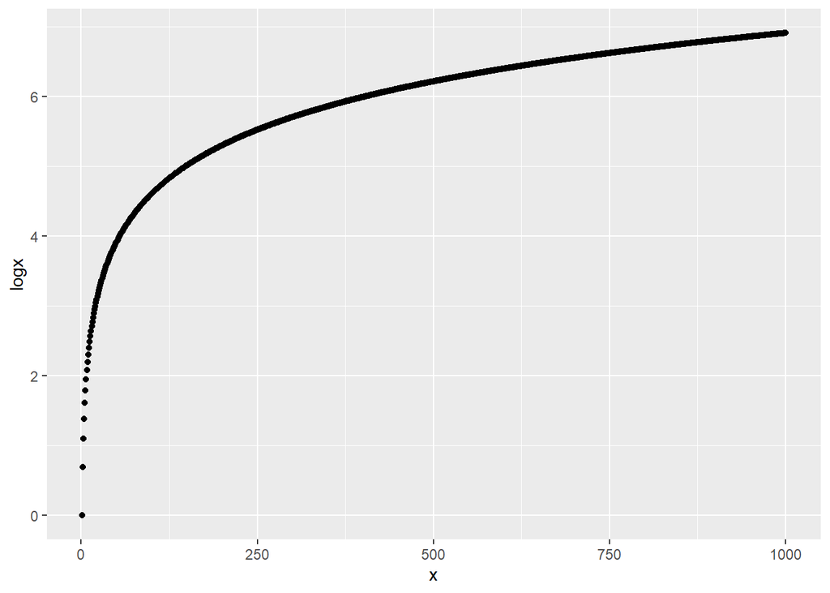

```r
x <- 1:1000
logx <- log(x)
qplot(x, logx)
```

Here are a few properties of logs that are useful to keep in mind.

```r
log(1) # log(1) == 0
```

```
## [1] 0
```

```r
log(2*3)
```

```
## [1] 1.791759
```

```r
log(2) + log(3) # log(z*w) == log(z) + log(w)
```

```
## [1] 1.791759
```

```r
log(2^3)
```

```
## [1] 2.079442
```

```r
3 * log(2) # log(z^w) == w * log(z)
```

```
## [1] 2.079442
```

```r
exp(log(5.4)) # exp(log(x)) == x, where exp() takes e (~= 2.72) and raises it to the value of the function's argument
```

```
## [1] 5.4
```

Notice that the `exp()` function (*exp*onentiate) effectively “un-logs” a quantity.

Now, create two new variables in the `ideal` dataset: `logprice`, the natural logarithm of `price`, and `logcarat`, the natural logarithm of `carat`. One way to do this for price would be to use the following code: `ideal$logprice <- log(ideal$price)`.

```r
ideal$logprice<-log(ideal$price)
ideal$logcarat<-log(ideal$carat)
view(ideal)
```

### 1a

Using the `qplot()` function twice, display two histograms of the `ideal` data frame.  
1. The first histogram should have `price` on the x-axis.  
2. The second histogram should have `logprice` on the x-axis.  
Notice how these two plots relate to the scatterplot above.

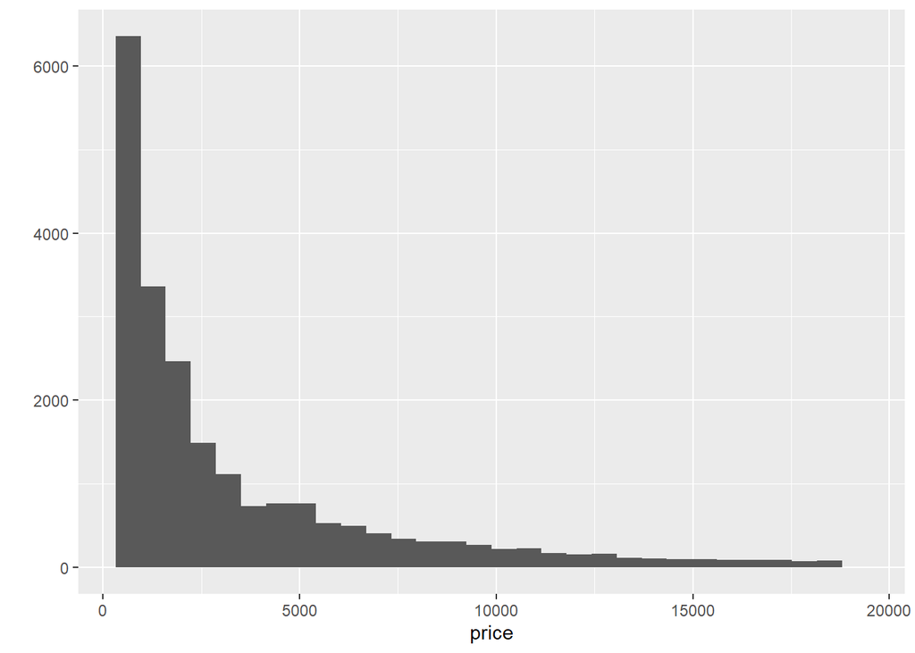

```r
qplot(x = price, data = ideal)
```

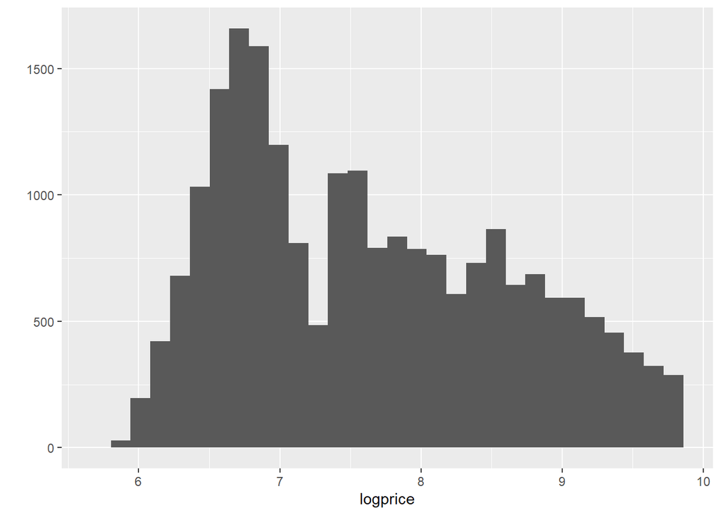

```r
qplot(x = logprice, data = ideal)
```

### 1b

Using the `qplot()` function three times, display three scatterplots of the `ideal` data frame.  
1. The second plot should have `carat` on the x-axis and `price` on the y-axis.  
2. The third should have `carat` on the x-axis and `logprice` on the y-axis.  
3. The fourth should have `logcarat` on the x-axis and `logprice` on the y-axis.  
Of these three plots, consider which of these relationships appears to be most suitable to be modeled via a **linear** relationship.

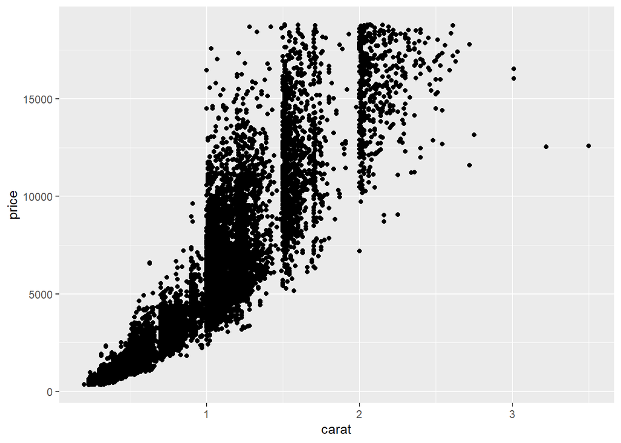

```r
qplot(x = carat, y = price, data = ideal,xlab = "carat", ylab = "price")
```

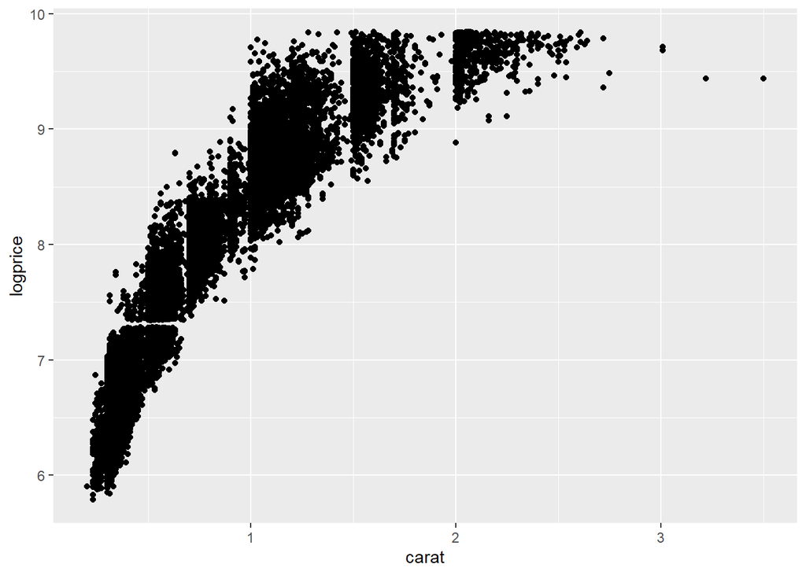

```r
qplot(x = carat, y = logprice, data = ideal,xlab = "carat", ylab = "logprice")
```

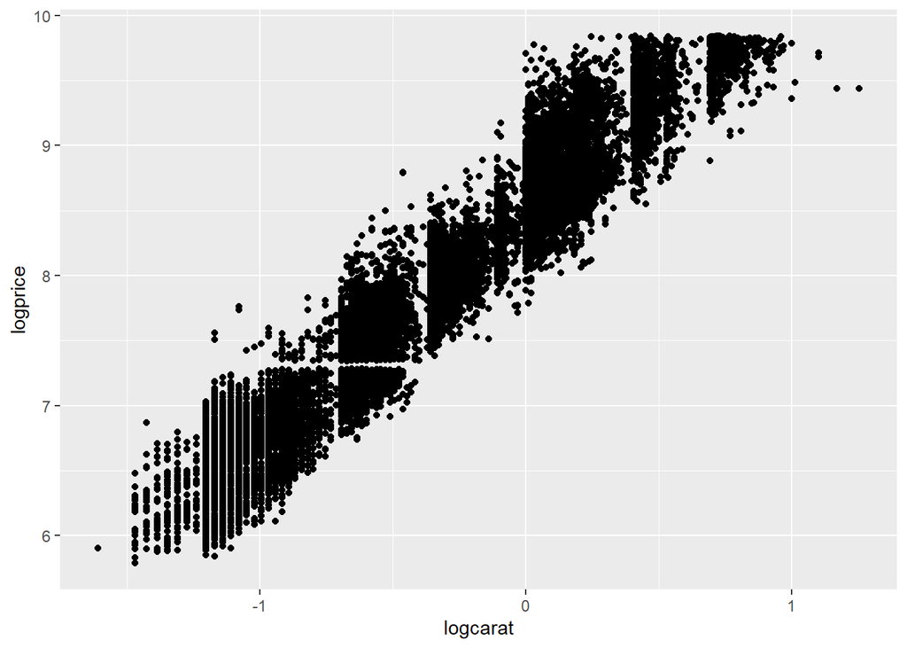

```r
qplot(x = logcarat, y = logprice, data = ideal,xlab = "logcarat", ylab = "logprice")
```

## Question 2

### 2a

Use the `lm()` function to estimate a linear model predicting `logprice` from `logcarat` for ideal diamonds. Name the output of the model `m1`. This question should be answerable with a single line of code.

(Note: In class, we took several different approaches to calculating the intercept and slope: the `lm()` function, the formulas for b0 and b1, thinking about “votes” and “weights”, and simulation by testing random lines through mean(x) and mean(y). Each approach led to the same coefficients; they just enable us to understand the solution from different angles. When we build models, we typically just use an approach like `lm()`.)

```r
m1 <- lm(formula = logprice ~ logcarat, data = ideal)
#str(m1)
summary(m1)
```

```
##
## Call:
## lm(formula = logprice ~ logcarat, data = ideal)
##
## Residuals:
##      Min       1Q   Median       3Q      Max
## -1.22162 -0.17106 -0.00164  0.16638  1.20135
##
## Coefficients:
##             Estimate Std. Error t value Pr(>|t|)
## (Intercept) 8.523274   0.002370  3595.6   <2e-16 ***
## logcarat    1.707240   0.003104   550.1   <2e-16 ***
## ---
## Signif. codes:  0 '***' 0.001 '**' 0.01 '*' 0.05 '.' 0.1 ' ' 1
##
## Residual standard error: 0.2559 on 21549 degrees of freedom
## Multiple R-squared:  0.9335, Adjusted R-squared:  0.9335
## F-statistic: 3.026e+05 on 1 and 21549 DF,  p-value: < 2.2e-16
```

```r
coef(m1)
```

```
## (Intercept)    logcarat
##    8.523274    1.707240
```

```r
model_coefs <- coef(m1)
```

### 2b

Report and interpret the intercept and slope of `m1`. Make sure to keep in mind what x and y are and how they have been transformed.

```r
model_coefs
```

```
## (Intercept)    logcarat
##    8.523274    1.707240
```

### 2c

You created `logprice` by taking the `log` of `price`. Recall from above that you can “un-log” by using the `exp()` function. So `exp(logprice)` should get you back to `price` in dollars.

Convert the intercept into (raw) dollars and interpret what it means. Remember what your x variable is and that log(1) = 0.

```r
exp(model_coefs[1])
```

```
## (Intercept)
##    5030.496
```

#### Answer 2c

**The converted intercept means if the diamond size is one carat, the price of the diamond is $5030.50**

### 2d

Using the `predict()` function, make two sets of predictions from `m1` when carat = .5, 1, and 1.5. (Note that you’ll need to calculate the appropriate values for logcarat.) First, report your prediction in log(dollars). Then report your prediction in raw (not log) dollars.

```r
carat_samples <- data.frame(logcarat=log(c(0.5,1.0,1.5)))
carat_samples
```

```
##     logcarat
## 1 -0.6931472
## 2  0.0000000
## 3  0.4054651
```

```r
price_samples <- predict(m1,newdata = carat_samples)

print("Prediction of logprice for carat sizes of 0.5, 1 and 1.5 carats")
```

```
## [1] "Prediction of logprice for carat sizes of 0.5, 1 and 1.5 carats"
```

```r
c(0.5,1.0,1.5)
```

```
## [1] 0.5 1.0 1.5
```

```r
print(price_samples)
```

```
##        1        2        3
## 7.339905 8.523274 9.215500
```

```r
print("Prediction of price for carat sizes of 0.5, 1 and 1.5 carats:")
```

```
## [1] "Prediction of price for carat sizes of 0.5, 1 and 1.5 carats:"
```

```r
c(0.5,1.0,1.5)
```

```
## [1] 0.5 1.0 1.5
```

```r
exp(price_samples)
```

```
##         1         2         3
##  1540.566  5030.496 10051.731
```

### 2e

Look at the difference between your predictions for carat = .5 and carat = 1, and the difference between your predictions for carat = 1 and carat = 1.5. Given that we use a linear prediction rule to predict Y from X, and 1-.5 = 1.5-1, why do neither our log(dollar) predictions nor our dollar predictions linearly increase with carats? Think carefully about how Y and X are scaled. We’ll discuss additional nuance in interpreting these kinds of models in more detail in Week 4.

#### Answer 2e

**Because we are increasing the carat linearly and we expect logrpice or price also increase linearly. But in reality, the X variable of the predictor is log(carat). If we use logcarat=(0.5,1.0,1.5), we would observe the linear behavior.**

## Question 3

### 3a

Write a new version of the `model_score` function from Week 2 code. Call this new version `model_score_int`. `model_score_int` should take three arguments: (1) a guess for the *intercept* (rather than a guess for the slope, as was used in `model_score`), (2) a vector of x’s, and (3) a vector of y’s. The function should use the guess for the intercept to calculate the slope that passes through the point (mean(x), mean(y)). Remember that if you given two points (like the point of means and the point represented by the intercept!) you can calculate the slope as (Y2-Y1) / (X2-X1). Using the line defined by the intercept passed to the function and the calculated slope as your prediction rule, calculate the sum of squared errors for the data given by x and y. (This chunk of code won’t generate any output.)

```r
model_score_int <- function(b0, x, y){
  b1 <- (mean(y) - b0) / mean(x)
  yhat <- b0 + b1 * x
  e <- y - yhat
  sum(e^2)
}
```

### 3b

Use `model_score_int` to assess SSE for the `ideal` data, predicting `logprice` from `logcarat`, given b0 = 8. What is SSE for that model?

```r
sse_sample <- model_score_int(b0 = 8, x = ideal$logcarat, y = ideal$logprice)
sse_sample
```

```
## [1] 8354.928
```

### 3c

Generate 1000 guesses for the intercept, drawn at random from a uniform distribution ranging from 6 to 10. Display the first 6 guesses.

```r
n_guess <- 1000
# 1000 random draws between 0 and 1000.
b0_guess <- runif(n = n_guess, min = 6, max = 10)
head(b0_guess)
```

```
## [1] 9.127019 7.903730 7.230113 8.809871 8.993819 6.423936
```

### 3d

Calculate a set of 1000 SSE using `map_dbl`, `model_score_int`, your guesses for the intercept, `ideal$logcarat` as x, and `ideal$logprice` as y. Display the first 6 values of SSE.

```r
sse <- map_dbl(b0_guess, model_score_int, x = ideal$logcarat, y = ideal$logprice)
length(sse)
```

```
## [1] 1000
```

```r
head(sse)
```

```
## [1]  10654.975  11145.118  43820.829   3493.824   7025.942 113181.532
```

```r
# min(sse)
```

### 3e

Plot SSE as a function of your b0 guesses.

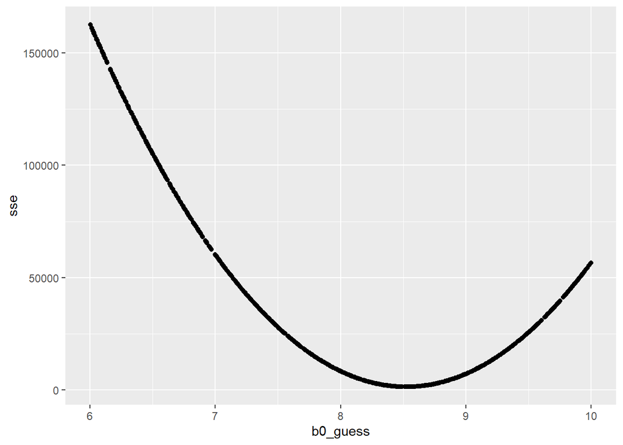

```r
qplot(b0_guess, sse)
```

### 3f

Discuss how the plot in (3e) relates to the coefficients you reported in (2b).

#### Answer 3f

**The minimum SSE (error) is happening where our guess for b0 is around 8.5. in part 2b we reazlized that the intercept found using the conventional lm() method by R by minimizing the error yields “8.523274”. This intercept matches the minimum point on the graph on the X axes.**

## Question 4

### 4a

Use the `anova()` function to calculate SST, SSR, and SSE for `m1`.

```r
anova(m1)
```

```
## Analysis of Variance Table
##
## Response: logprice
##              Df  Sum Sq Mean Sq F value    Pr(>F)
## logcarat      1 19809.7 19809.7  302594 < 2.2e-16 ***
## Residuals 21549  1410.7     0.1
## ---
## Signif. codes:  0 '***' 0.001 '**' 0.01 '*' 0.05 '.' 0.1 ' ' 1
```

### 4b

What is the value of SSR?

#### Answer 4b

**SSR = 19809.7**

### 4c

What is the value of SSE?

#### Answer 4c

**SSE = 1410.7**

### 4d

What is the value of SST?

#### Answer 4d

**SST= SSR + SSE = 21220.4**

### 4e

What is R^2? Confirm that the R^2 you calculated from the numbers above matches the R^2 from `summary(m1)`.

```r
ssr_m1 <- 19809.7/21220.4
ssr_m1
```

```
## [1] 0.9335215
```

```r
summary(m1)
```

```
##
## Call:
## lm(formula = logprice ~ logcarat, data = ideal)
##
## Residuals:
##      Min       1Q   Median       3Q      Max
## -1.22162 -0.17106 -0.00164  0.16638  1.20135
##
## Coefficients:
##             Estimate Std. Error t value Pr(>|t|)
## (Intercept) 8.523274   0.002370  3595.6   <2e-16 ***
## logcarat    1.707240   0.003104   550.1   <2e-16 ***
## ---
## Signif. codes:  0 '***' 0.001 '**' 0.01 '*' 0.05 '.' 0.1 ' ' 1
##
## Residual standard error: 0.2559 on 21549 degrees of freedom
## Multiple R-squared:  0.9335, Adjusted R-squared:  0.9335
## F-statistic: 3.026e+05 on 1 and 21549 DF,  p-value: < 2.2e-16
```

#### Answer 4e

**R^2 = SSR / SST = 1 - (SSE / SST) = 93.35%**

## Question 5

### 5a

Make a plot of the residuals of `m1` on the y-axis and `logcarat` on the x-axis.

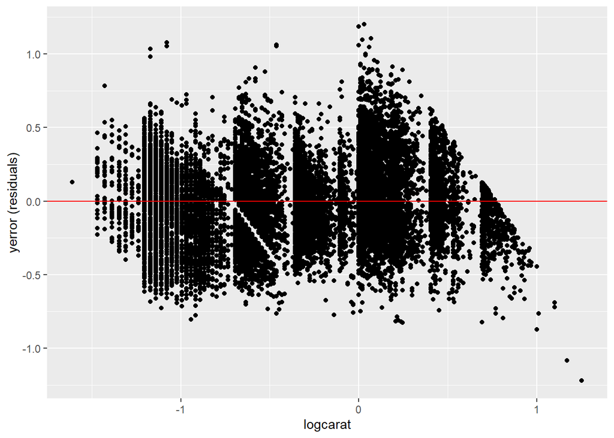

```r
ydata <- ideal$logprice

# we are not sending data to predict. So it uses the previous data and y of the original fit to the data.
yfit <- predict(m1)
yerror <- residuals(m1)
# for plotting purposes only
m2 <- lm(residuals(m1) ~ ideal$logcarat)

qplot(x=ideal$logcarat, y=yerror,xlab = "logcarat", ylab = "yerror (residuals)") + geom_abline(intercept=coef(m2)[1], slope=coef(m2)[2], color = "red")
```

### 5b

Describe (in words) where the best fit line predicting residuals from logcarat on the plot above would lie. Why would it be there? (You do not need to explicitly model this using `lm()`, but doing so should give you the same answer.)

#### Answer 5b

**The residuals are all scattered around the Y axis, meaning that the best line to predict residuals from logcarat lies on the horizontal line at Y=0. It implies that the y error (residuals) are not correlated to the feature on the X axis. Therefore our regression model cannot benefit from any information from the error and is the best model possible.**

## Question 6

Make sure that you have read Chapters [2](https://moderndive.com/2-viz.html) and [3](https://moderndive.com/3-wrangling.html) in *ModernDive*. Once you have, describe in your own words what the code chunk below will do.

```r
diamonds %>%
  mutate(price_carat = price / carat) %>%
  group_by(cut) %>%
  summarize(m_price_carat = mean(price_carat))
```

```
## # A tibble: 5 x 2
##   cut       m_price_carat
##   <ord>             <dbl>
## 1 Fair              3767.
## 2 Good              3860.
## 3 Very Good         4014.
## 4 Premium           4223.
## 5 Ideal             3920.
```

#### Answer 6

1. First the **pipe** operator sends “diamonds” data to **mutate** function.
2. **mutate** function defines a new feature and add it to “diamonds” dataframe. Then the pipe operator sends the entire dataframe with the new feature to **group_by**
3. **group_by** function, groups rows by“$cut” feature in the next step after the pipe operation.
4. **summarize** shows the average of **price_carat** we just calculated earlier for different categories of the cut.

# Section 2

# Part 1: Hypothesis Testing and p values

Our null hypothesis, $H_0$, is a hypothesis that a population parameter $\beta$ takes on some specific value $\beta^*$ (often 0). For example, we may hypothesize that the intercept in the market model is 0 ($H_0: \beta_0 = 0$, where $\beta_0^*$ is 0). The alternative hypothesis, $H_A$, is that the population parameter $\beta$ takes on some value other than $\beta^*$. For example, for the case above, our alternative hypothesis would be that the intercept in the market model is something other than 0 ($H_A: \beta_0 \ne 0$, again where $\beta_0^*$ is 0).

We never directly observe population parameters like $\beta_0$, and our sample estimate will never precisely equal the population parameter. But we can get an assessment of how likely we would be to observe a deviation from our null hypothesis (e.g., $b_0-\beta_0^*$) at least as big as the one we actually observed, if the null hypothesis were true. This depends on the sampling error of our estimate, $s_{b_1}$, and is assessed using the t distribution, where $t = (b_0-\beta_0^*)/s_{b_0}$ (in the case of the intercept) or $t = (b_1-\beta_1^*)/s_{b_1}$ (in the case of the slope).

If the null hypothesis ($H_0$) were true, $|t|$ will usually be < 2. If $|t|$ is sufficiently large (larger than the critical value, $t^*_{N-2,\alpha/2}$), this means that we’d be unlikely to observe a discrepancy this large or larger if the null hypothesis were true. Typically we set our statistical significance level ($\alpha$) to be .05. If the probability of observing an estimate at least this extreme if the null hypothesis were true were less than 5%, then we reject the null hypothesis. The logic amounts to saying “if the null hypothesis were true, we probably would not have observed an estimate this extreme, so the null hypothesis must not be true.” For example, for the VGENX Vanguard fund, “if the null hypothesis were true that $\beta_1$ were equal to 0, the chance of observing an estimate $b_1$ that is at least this big given $s_{b_1}$ is considerably smaller than 5%, so we reject the null hypothesis.” The probability of observing an estimate at least as extreme as the observed estimate if the null hypothesis were true is the p value.

The p value is NOT the probability the null hypothesis is true. The p value is NOT the probability that our results are due to chance. It is the probability that the null hypothesis would generate an estimate at least as extreme as we observed if the null hypothesis were true.

## Step 1

First, recreate the `simreg()` function from Week 4 code. As a reminder, this function takes `beta0`, `beta1`, `sigma`, and a vector `x` as arguments, and returns a vector of simulated datapoints given those x’s and that model. You can copy and paste the function definition in the code chunk below.

#### Your knitted html does not need to include any output for this step.

```r
library(tidyverse)
simreg <- function(beta0, beta1, sigma, x){
  err <- rnorm(length(x), sd = sigma)
  beta0 + beta1 * x + err
}
```

## Step 2

Second, define a second function modeled after `gen_sample_coef()` from Week 4. (You may find it useful to copy-paste the function definition in the code chunk below, and then make adjustments to it.) However, whereas `gen_sample_coef()` returned a sample **slope**, your function here should return a **vector of length two**, where the first element is the sample **intercept** and the second element is **$s_{b_0}$**. Note that using `coef(m_sim)` won’t work here, as it does not return the standard error. Instead, you can use `coef(summary(m_sim))[1, 1:2]`. This will take the coefficients table from the summary output (which does include the standard errors) and returns the first and second columns of the first row, in other words, the estimate and standard error for the intercept.

#### Your knitted html does not need to include any output for this step.

```r
gen_sample_coef <- function(beta0_to_sim, beta1_to_sim, sigma_to_sim, xs){
  ys <- simreg(beta0 = beta0_to_sim, beta1 = beta1_to_sim,
               sigma = sigma_to_sim, x = xs)
  m_sim <- lm(ys ~ xs)
  coef(summary(m_sim))[1, 1:2]
}
```

## Step 3

Now, use `replicate()` to generate 1,000 estimates of the intercept and its standard error given $\beta_0 = 0$, $\beta_1 = 1$, $\sigma = .025$, and x given by the 436 `vwretd` values from our usual `join_van` dataset. (Note that you’ll need to recreate the `join_van` dataset here from the `Vanguard` and `marketRf` datasets before you can use it, just like we did in class in weeks 4 and 5. If you haven’t restarted R recently, your code may appear to work, if `join_van` is in your environment, but then the .rmd file will not knit, as it won’t generate `join_van` on its own.)

When `replicate()` uses a function that returns more than a single element, the formatting isn’t quite as easy to work with. First, review how we’ve used replicate in Weeks 4 and 5 in class. Then, I recommend using the following adjustments when you call `replicate()`:

`out_df <- as.data.frame(t(replicate(YOUR REPLICATE ARGUMENTS (N AND FUNCTION) GO HERE)))`  
`colnames(out_df) <- c("b0", "sb0")`

The first line takes the output of replicate, transposes it (using the `t()` function), then makes it into a `data.frame` and assigns it to `out_df`. The second line renames the variables, by renaming the column names.

#### Your knitted html does not need to include any output for this step.

```r
Vanguard <- read_csv("Vanguard.csv")
marketRf <- read_csv("marketRf.csv")
wide_van <- Vanguard %>%
  select(date, ticker, mret) %>%
  pivot_wider(names_from = ticker, values_from = mret)
join_van <- left_join(wide_van, select(marketRf, date, vwretd), by = "date")

num_samples <- 1000
truebeta0 <- 0
truebeta1 <- 1
truesigma <- 0.025

out_df <- as.data.frame(t(replicate(num_samples,
                   gen_sample_coef(beta0_to_sim = truebeta0, beta1_to_sim = truebeta1,
                                   sigma_to_sim = truesigma, xs = join_van$vwretd))))
colnames(out_df) <- c("b0", "sb0")
```

## Step 4

This should give you a data frame of 1,000 coefficient estimates (as variable `b0`) and their corresponding 1,000 standard errors (as variable `sb0`). You may want to inspect `out_df` at this point to make sure it looks reasonable. Remember that these were generated by simulating data where the true intercept is 0. Taking the null hypothesis that $\beta_0 = 0$, you can use those simulated values to calculate the corresponding 1,000 $t$ statistics as the ratio of $b_0$ to $s_{b_0}$. Store those $t$ statistics in a new variable in the same data frame called `t_stat` and make a histogram of `t_stat` using `qplot()`.

#### Your knitted html should include that histogram in its output.

```r
out_df <- mutate(out_df,t_stat=b0/sb0)
p1<-qplot(out_df$t_stat,xlab="t-statistics")
```

## Step 5

Calculate the critical value of $t$. You can calculate this using the `qt()` function discussed in class in Week 5. For $\alpha = .05$, consider how much mass should be in the right tail and how much in the left tail, and how many degrees of freedom you need. (Remember that your answer for the critical value should be very close to 2. **If it’s not near 2, it’s wrong.**)

#### Your knitted html should display the critical value of $t$.

```r
qt(.975, df = 434)
```

```
## [1] 1.965445
```

```r
qt(.025, df = 434)
```

```
## [1] -1.965445
```

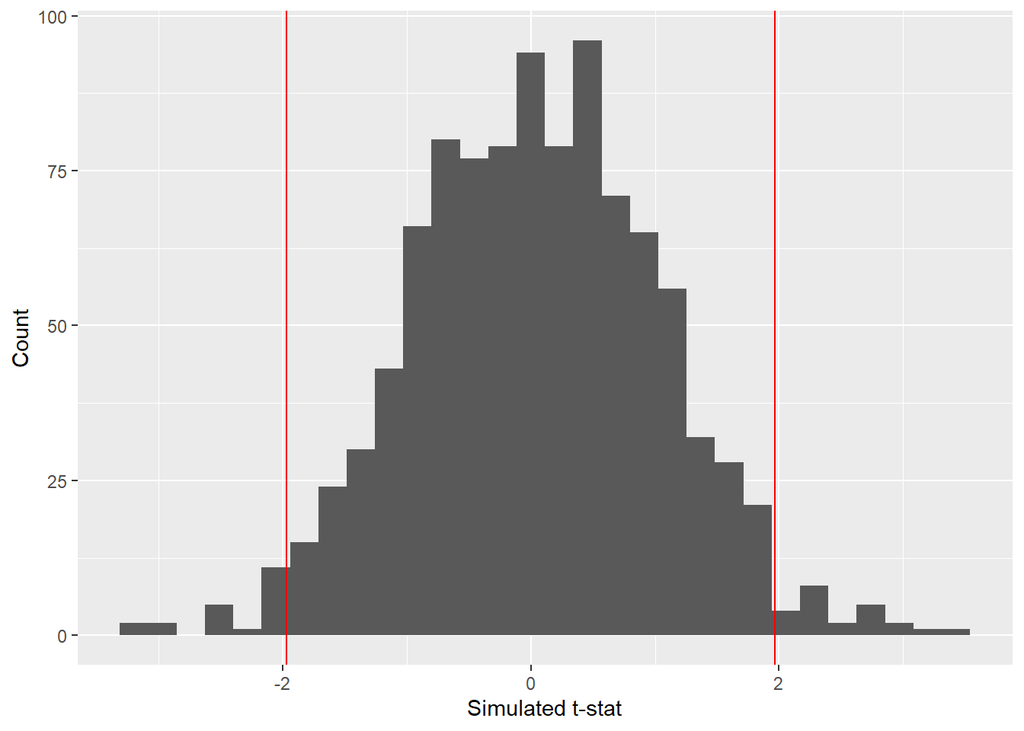

```r
ggplot(data = out_df, aes(x = t_stat)) +
  geom_histogram() +
  xlab("Simulated t-stat") +
  ylab("Count") +
  geom_vline(xintercept = qt(.975, df = 434),color="red")+geom_vline(xintercept = qt(0.025, df = 434),color="red")
```

```r
#(p2 <- p1+qplot(qt(.975, df = 998)*rep(1, 10000),c(1:10000),color = "red"))
```

## Step 6

On what proportion of samples did you reject the null hypothesis? That is, on what proportion of samples did you find $|t|$ to be greater than the absolute value of the critical value calculated in Question 4? If you use the command `abs(x) > qt(p, df)`, you’ll get a vector of 1,000 `TRUE` and `FALSE` values where it takes a value of `TRUE` if `abs(x)` is greater than `qt(p, df)` and it takes a value of `FALSE` if `abs(x)` is less than or equal to `qt(p, df)`. Because `TRUE` is treated as 1 and `FALSE` is treated as 0, taking the average of that vector will give you the proportion of cases where the inequality holds. Your answer ought to be close to 0.05.

#### Your knitted html should display that proportion.

```r
beyond_lim<-abs(out_df$t_stat) > qt(.975, df = 434)
mean(beyond_lim)
```

```
## [1] 0.042
```

## Step 7

Now repeat that process using `gen_sample_coef()` below to simulate 1,000 new samples of returns for the case where $\beta_0 = .002$ rather than $\beta_0 = 0$, but all other inputs are the same. On what proportion of these new samples do you reject the null hypothesis? Consider what this means for your ability to detect whether a fund manager is in fact generating a small amount of alpha (though you don’t need to include that consideration in your answer.)

#### Your knitted html should display that proportion.

```r
num_samples <- 1000
truebeta0 <- 0.002
truebeta1 <- 1
truesigma <- 0.025

out_df2 <- as.data.frame(t(replicate(num_samples,
                   gen_sample_coef(beta0_to_sim = truebeta0, beta1_to_sim = truebeta1,
                                   sigma_to_sim = truesigma, xs = join_van$vwretd))))
colnames(out_df2) <- c("b0", "sb0")

out_df2 <- mutate(out_df2,t_stat=b0/sb0)
#qplot(out_df2$t_stat,xlab="t-statistics")

#qt(.975, df = 998)
#qt(.025, df = 998)

beyond_lim<-abs(out_df2$t_stat) > qt(.975, df = 434)
mean(beyond_lim)
```

```
## [1] 0.396
```

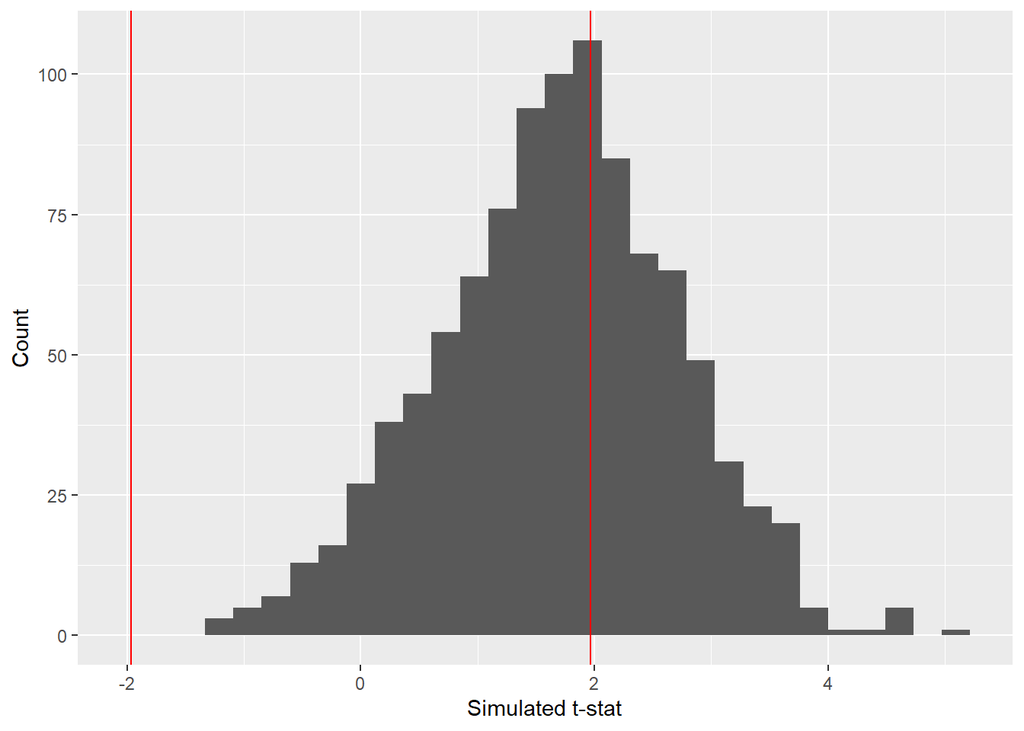

```r
ggplot(data = out_df2, aes(x = t_stat)) +
  geom_histogram() +
  xlab("Simulated t-stat") +
  ylab("Count") +
  geom_vline(xintercept = qt(.975, df = 434),color="red")+geom_vline(xintercept = qt(0.025, df = 434),color="red")
```